# Correlations of gage info with Pekel data

#### *All gages in the 50 Central Valley HUCs are queried*

#### Workflow

- Retrieve previously compiled Pekel data (JRC Global Surface Monthly Water History) from all CV HUCs over 2 extents
  - ‘Unbuffered’ - full HUC
  - ‘Buffered’ - within 500m of stream extents only
- Clean Pekel data
  - Restrict values to those from images with < 1% NoData pixels
- Retrieve stage height and discharge data from all CV stream gages (NWIS)
- Calculate Pearson correlation between gage info and Pekel extents
- Retrieve linear fit coefficients
- Apply coefficients to stream gage data to estimate missing Pekel data

Slightly more buffered than unbuffered data types (262 vs. 206) were associated with higher correlations at each site.

The highest Pearson correlations between monthly Pekel data and monthly streamgage discharge/height data for each HUC are below. Bolded values are > 0.5.

#### Maximum correlation in each HUC

| HUC | Gage | Pekel data | Parameter | r | n |
| --- | --- | --- | --- | --- | --- |
| 18020002 | 11351945 | unbuffered | discharge | 0.7155232 | 49 |
| 18020003 | 11362950 | unbuffered | discharge | 0.8782777 | 95 |
| 18020004 | 11367500 | unbuffered | discharge | 0.7908985 | 89 |
| 18020005 | 11342000 | unbuffered | discharge | 0.5151454 | 110 |
| 18020104 | 11389500 | buffered | discharge | 0.3228654 | 180 |
| 18020111 | 11446500 | buffered | discharge | 0.4914510 | 180 |
| 18020116 | 11450000 | unbuffered | gage ht | 0.7671927 | 193 |
| 18020121 | 11404900 | unbuffered | discharge | 0.5322698 | 128 |
| 18020122 | 11401920 | unbuffered | discharge | 0.6681172 | 27 |
| 18020123 | 11396395 | unbuffered | discharge | 0.8146864 | 77 |
| 18020125 | 11413323 | buffered | discharge | 0.8454259 | 82 |
| 18020126 | 11423800 | buffered | discharge | 0.6617975 | 153 |
| 18020128 | 11427770 | unbuffered | discharge | 0.7126676 | 109 |
| 18020129 | 11436510 | buffered | discharge | 0.7169556 | 19 |
| 18020151 | 11372330 | unbuffered | discharge | 0.7073722 | 104 |
| 18020152 | 11374300 | buffered | discharge | 0.7545100 | 41 |
| 18020153 | 11376160 | buffered | discharge | 0.6173232 | 129 |
| 18020154 | 11371600 | buffered | discharge | 0.2647834 | 171 |
| 18020155 | 11377100 | buffered | discharge | 0.6326314 | 198 |
| 18020156 | 11381500 | unbuffered | discharge | 0.6783892 | 125 |
| 18020157 | 11383500 | unbuffered | discharge | 0.6575320 | 159 |
| 18020158 | 11389720 | unbuffered | discharge | 0.5654060 | 127 |
| 18020159 | 11406930 | unbuffered | discharge | 0.2545626 | 185 |
| 18020161 | 11425500 | buffered | discharge | 0.0598704 | 190 |
| 18020162 | 11453500 | buffered | discharge | 0.5745510 | 127 |
| 18020163 | 11453000 | buffered | discharge | 0.7692464 | 17 |
| 18030001 | 11186001 | unbuffered | discharge | 0.7327307 | 59 |
| 18030002 | 11189500 | unbuffered | discharge | 0.4831582 | 149 |
| 18030003 | 11192500 | buffered | discharge | 0.7663668 | 184 |
| 18030005 | 11200800 | unbuffered | discharge | 0.4970706 | 215 |
| 18030006 | 11201450 | unbuffered | discharge | 0.7737785 | 115 |
| 18030007 | 11206820 | unbuffered | discharge | 0.8846613 | 9 |
| 18030009 | 11253310 | unbuffered | discharge | 0.4512160 | 190 |
| 18030010 | 11218700 | unbuffered | discharge | 0.7729045 | 18 |
| 18030012 | 11224500 | unbuffered | discharge | 0.3120235 | 192 |
| 18040001 | 11273400 | buffered | discharge | 0.8643214 | 36 |
| 18040002 | 11274550 | buffered | discharge | 0.9503570 | 153 |
| 18040003 | 11337600 | buffered | discharge | 0.5558578 | 87 |
| 18040006 | 11224000 | buffered | discharge | 0.8792405 | 11 |
| 18040008 | 11269700 | buffered | discharge | 0.7499117 | 95 |
| 18040009 | 11290000 | unbuffered | discharge | 0.6648866 | 83 |
| 18040010 | 11292615 | buffered | discharge | 0.8187616 | 28 |
| 18040012 | 11313482 | buffered | discharge | 0.6534017 | 49 |
| 18040013 | 11335000 | unbuffered | discharge | 0.7729845 | 160 |
| 18040014 | 11255575 | buffered | discharge | 0.2472893 | 28 |

#### Individual correlations

Highest correlation: HUC 18040002, gage 11274550 (r = 0.95)

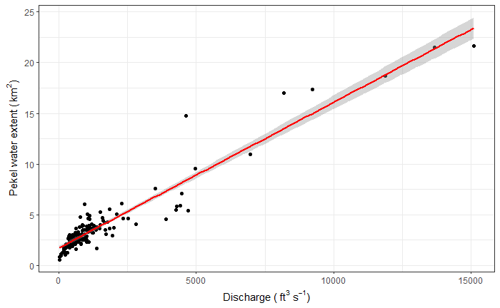

Lowest maximum correlation: HUC 18020161, gage 11425500 (r = 0.06)

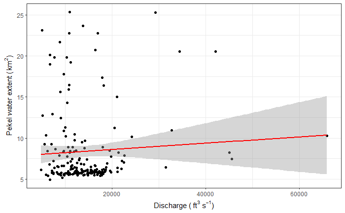

There are some odd correlations, such as HUC 18040009, site 11359200, which has r = -0.67:

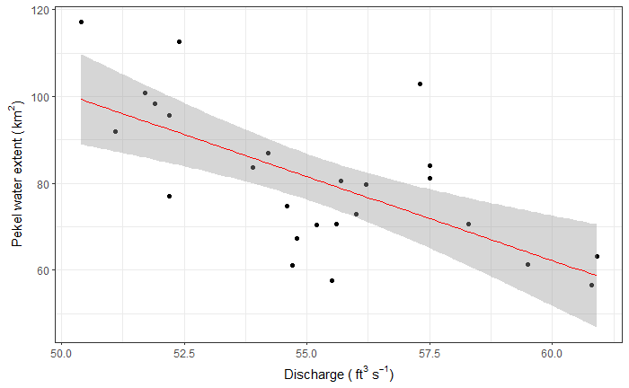

#### Estimating surface water extent based on correlations

What does the maximum correlation look like as far as augmenting associated Pekel data?

If we replace missing Pekel data water values with the equation

$y = 1.7265863 + 0.0014363x_i$

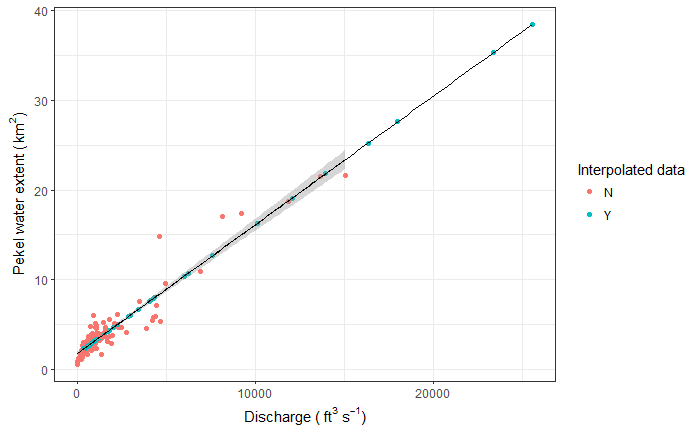

the augmented Pekel time series yields the following:

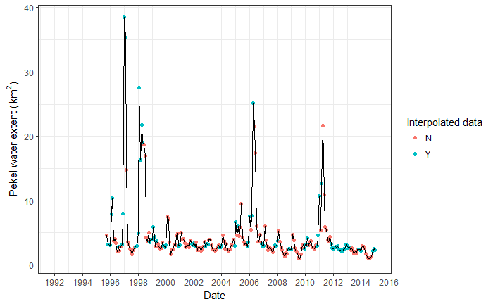

Note that the interpolation mostly fills in low Pekel data values, but also contributes prominent peaks that were missing from the original Pekel time series.

Given the high correlation, it’s no surprise that the corresponding stream gage monthly data looks very similar:

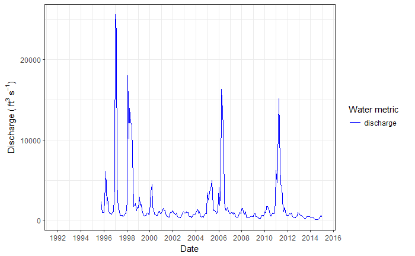

#### HUC-specific comparison

Now examine all sites within that one HUC to assess how different values of surface water extent might be derived from different gage correlations. Plots are shown in order from the highest to lowest correlation values. (Buffered and unbuffered plots have different y-axis ranges and cannot be directly compared)

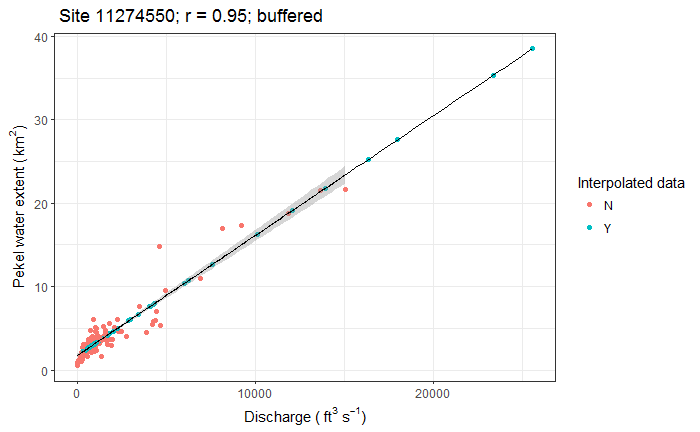

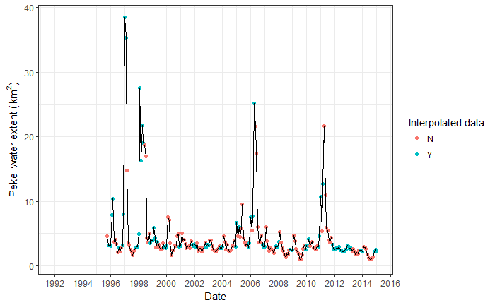

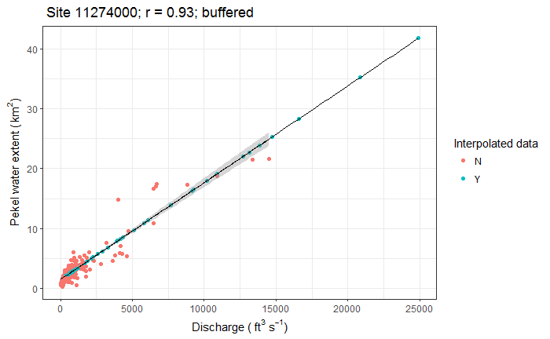

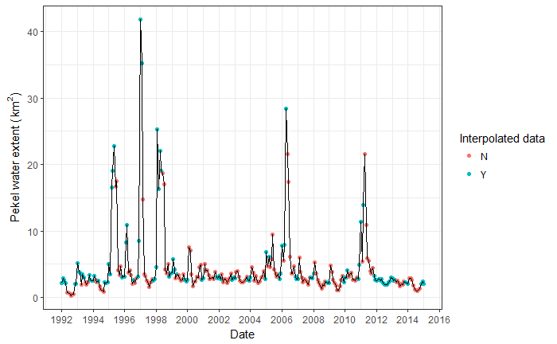

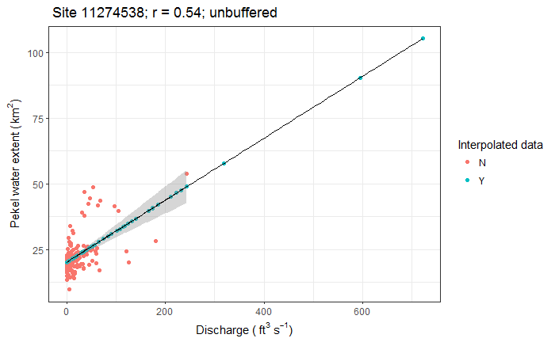

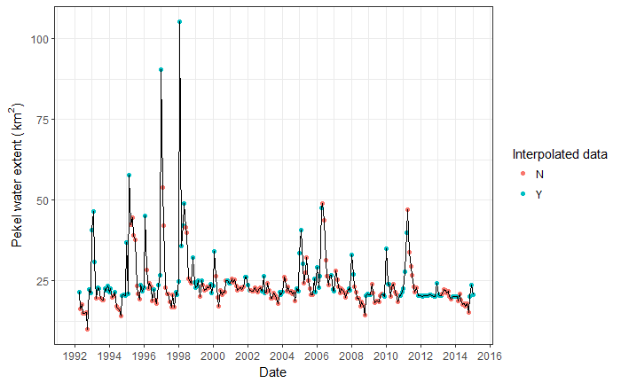

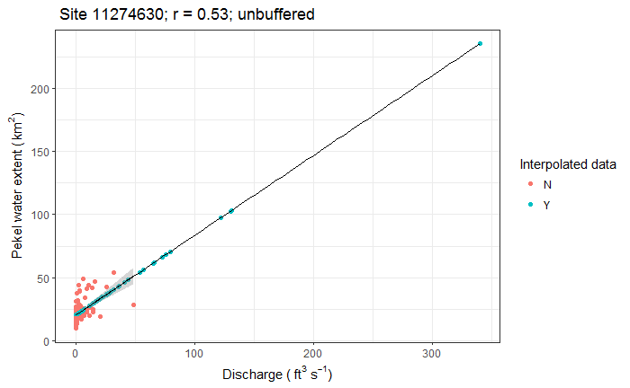

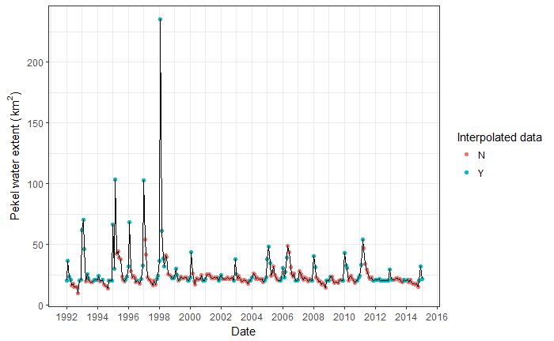

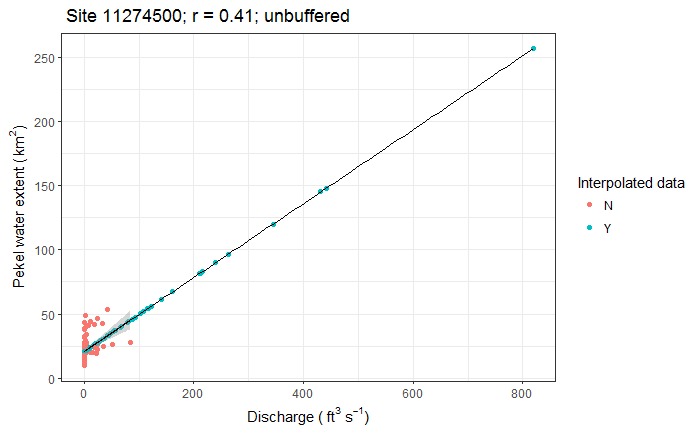

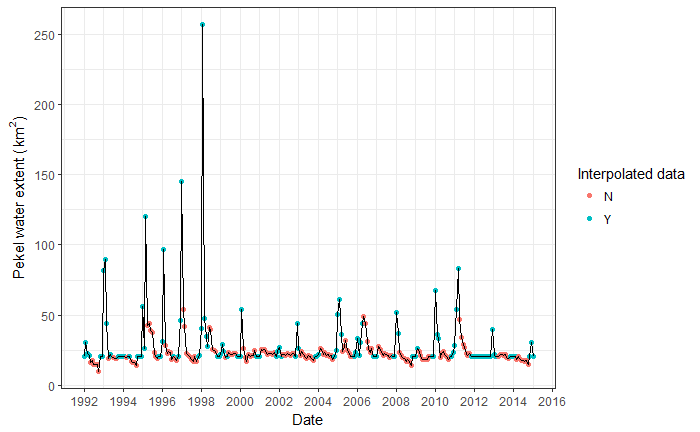

#### Gage locations

[figure not shown]

#### Notes

- Discharge is the most typical reported gage metric
- Even gages on the same river (11274550; 11274000) with respectively high correlations result in different estimates of surface water extent
- Lower correlation gages are on smaller order streams
- No noise removal was performed on the gage data. Can there be spurious gage values?
- All correlations assume a linear fit, though more complex relationships may exist
- Buffered vs. unbuffered data
  - Unbuffered allows for the calculation of surface water across entire HUC
  - Buffered permits narrower focus on streams (currently undifferentiated)
- What about extending the comparison of gage values to surface water in any given HUC–any likely connection?